# Tuning kNN using `caret`

Shih Ching Fu

August 2020

This notebook describes an example of using the `caret`[^1] package to conduct hyperparameter tuning for the k-Nearest Neighbour classifier.

```r
library(mclust)
library(dplyr)
library(ggplot2)
library(caret)
library(pROC)
```

# 1 Example dataset

The example dataset is the `banknote` dataframe found in the `mclust`[^2] package. It contains six measurements made on 100 genuine and 100 counterfeit old-Swiss 1000-franc bank notes.

```r
data(banknote)
head(banknote)
```

|  | Status | Length | Left | Right | Bottom | Top | Diagonal |
| --- | --- | --- | --- | --- | --- | --- | --- |
| 1 | genuine | 214.8 | 131.0 | 131.1 | 9.0 | 9.7 | 141.0 |
| 2 | genuine | 214.6 | 129.7 | 129.7 | 8.1 | 9.5 | 141.7 |
| 3 | genuine | 214.8 | 129.7 | 129.7 | 8.7 | 9.6 | 142.2 |
| 4 | genuine | 214.8 | 129.7 | 129.6 | 7.5 | 10.4 | 142.0 |
| 5 | genuine | 215.0 | 129.6 | 129.7 | 10.4 | 7.7 | 141.8 |
| 6 | genuine | 215.7 | 130.8 | 130.5 | 9.0 | 10.1 | 141.4 |

There are six predictor variables (`Length`, `Left`, `Right`, `Bottom`, `Top`, `Diagonal`) with `Status` being the categorical response or class variable having two levels, namely `genuine` and `counterfeit`.

# 2 Exploratory data analysis

Observe that the dataset is balanced with 100 observations against each level of `Status`.

```r
banknote %>%
  group_by(Status) %>%
  summarise(N = n(),
            Mean_Length = mean(Length),
            Mean_Left = mean(Left),
            Mean_Right = mean(Right),
            Mean_Bottom = mean(Bottom),
            Mean_Top = mean(Top),
            Mean_Diagonal = mean(Diagonal),
            .groups = "keep")
```

| Status | N | Mean_Length | Mean_Left | Mean_Right | Mean_Bottom | Mean_Top | Mean_Diagonal |
| --- | --- | --- | --- | --- | --- | --- | --- |
| counterfeit | 100 | 214.823 | 130.300 | 130.193 | 10.530 | 11.133 | 139.450 |
| genuine | 100 | 214.969 | 129.943 | 129.720 | 8.305 | 10.168 | 141.517 |

In most of the measurements of bank notes aside from `Length`, genuine and counterfeit notes have quite distinct distributions.

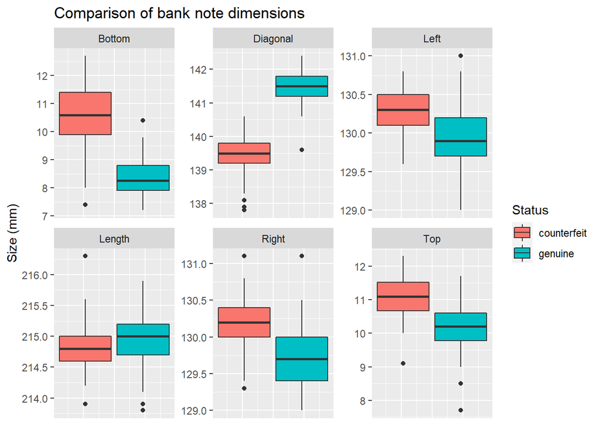

```r
library(tidyr)
banknote %>%
  mutate(ID = 1:n()) %>%
  pivot_longer(Length:Diagonal,
               names_to = "Dimension",
               values_to = "Size") %>%
  mutate(Dimension = factor(Dimension),
         ID = factor(ID)) %>%
  ggplot() +
  aes(y = Size, fill = Status) +
  facet_wrap(~ Dimension, scales = "free") +
  geom_boxplot() +
  theme(axis.text.x = element_blank(),
        axis.ticks.x = element_blank()) +
  labs(y = "Size (mm)", title = "Comparison of bank note dimensions")
```

Below is a visualisation of the distribution of the perimeters of the bank notes.

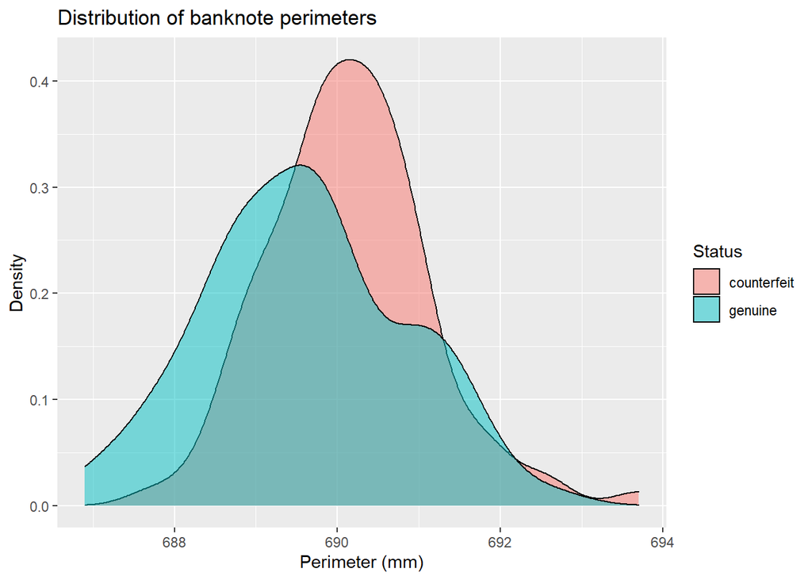

```r
banknote %>%
  mutate(Perimeter = 2*Length + Left + Right) %>%
  ggplot() +
  aes(x = Perimeter, fill = Status) +
  geom_density(alpha = 0.5) +
  labs(x = "Perimeter (mm)", y = "Density", title = "Distribution of banknote perimeters")
```

# 3 Split dataset

Create training and testing datasets, preserving the 50/50 class split in each.

```r
set.seed(1)
training_index <- createDataPartition(banknote$Status,
                                      p = 0.8,
                                      list = FALSE)

training_set <- banknote[training_index, ]
testing_set <- banknote[-training_index, ]
```

We can confirm the class split in the training set:

```r
table(training_set$Status)
```

```
##
## counterfeit     genuine
##          80          80
```

# 4 Hyper-parameter tuning

Set up the cross-validation for hyperparameter tuning, i.e., 10-fold cross validation repeated 10 times.

The `summaryFunction` argument determines which metric to use to determine the performance of a particular hyperparameter setting. Here we shall use `defaultSummary` which calculates accuracy and kappa statistic.

```r
training_control <- trainControl(method = "repeatedcv",
                                 summaryFunction = defaultSummary,
                                 classProbs = TRUE,
                                 number = 10,
                                 repeats = 10)
```

Now use the `train()` function to perform the model training/tuning of the `k` hyperparameter.

```r
set.seed(2)
knn_cv <- train(Status ~ .,
                data = training_set,
                method = "knn",
                trControl = training_control,
                metric = "Accuracy",
                tuneGrid = data.frame(k = seq(11,85,by = 2)))
knn_cv
```

```
## k-Nearest Neighbors
##
## 160 samples
##   6 predictor
##   2 classes: 'counterfeit', 'genuine'
##
## No pre-processing
## Resampling: Cross-Validated (10 fold, repeated 10 times)
## Summary of sample sizes: 144, 144, 144, 144, 144, 144, ...
## Resampling results across tuning parameters:
##
##   k   Accuracy  Kappa
##   11  0.993750  0.98750
##   13  0.993750  0.98750
##   15  0.996875  0.99375
```

[output cut: 38 more lines]

The cross-validation on the training set has tuned a `k` parameter of 73.

## 4.1 ROC Curve

Inspecting the probabilities reveals that a cutoff probability around 0.5 give good classification results.

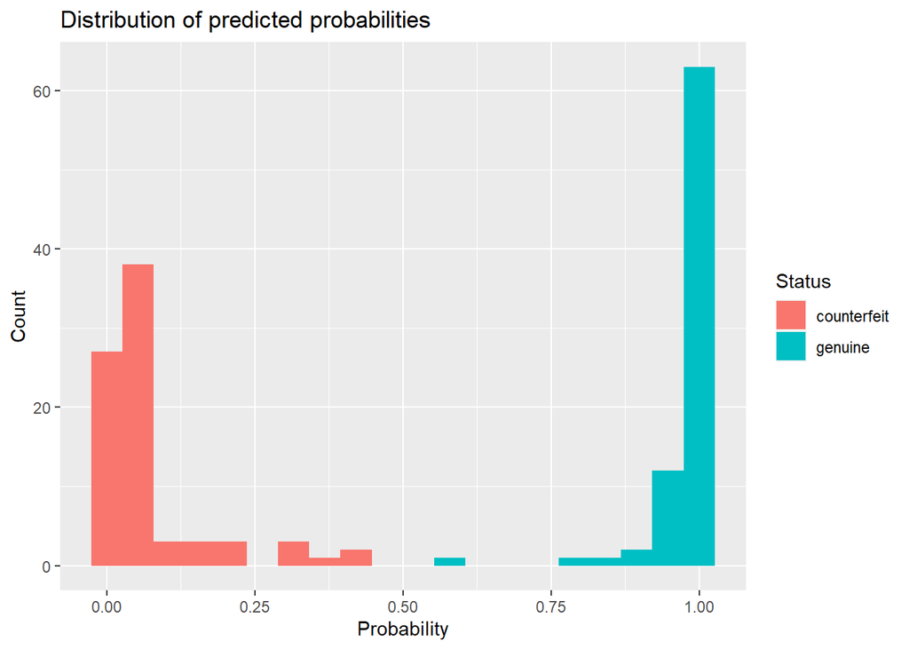

```r
training_set <- training_set %>%
  mutate(Predicted_prob = predict(knn_cv, type = "prob")$genuine)

training_set %>%
  ggplot() +
  aes(x = Predicted_prob, fill = Status) +
  geom_histogram(bins = 20) +
  labs(x = "Probability", y = "Count", title = "Distribution of predicted probabilities" )
```

An ROC curve is another way to visualise the results and identify a good cutoff.

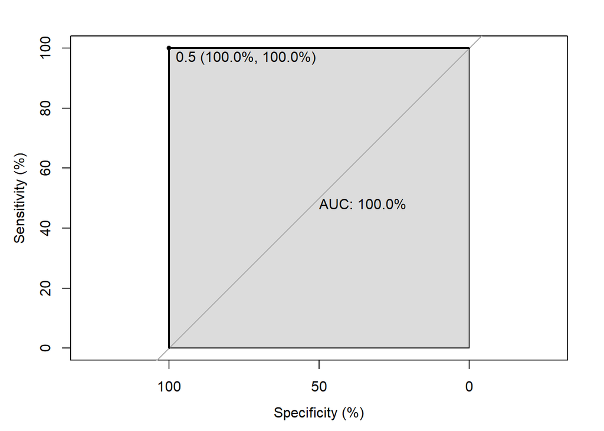

```r
pROC_train <- roc(training_set$Status, training_set$Predicted_prob,
                quiet = TRUE,
                plot = TRUE,
                percent = TRUE,
                auc.polygon = TRUE,
                print.auc = TRUE,
                print.thres = TRUE,
                print.thres.best.method = "youden")
```

According to the Youden criterion on the training set, the best threshold is 0.5. Choosing this as the cutoff probability returns a perfect classification result on the training data. Be wary of overfitting the training data however.

# 5 kNN classification

Apply the final model, with k = 73 and cutoff = 0.5, to the testing dataset to get an estimate of the true performance of this classifier.

```r
knn_predictions <- predict(knn_cv, newdata = testing_set, type = "prob") %>%
  select(probability = genuine) %>%
  mutate(class = ifelse(probability > 0.5, "genuine", "counterfeit")) %>%
  mutate(class = factor(class))
```

The results on the testing dataset are evenly split between the two classes which is a good sign!

```r
table(knn_predictions$class)
```

```
##
## counterfeit     genuine
##          20          20
```

Since we have the ground truth data, we can use the `confusionMatrix()` function to report full set of performance statistics.

```r
knn_cm <- confusionMatrix(knn_predictions$class, testing_set$Status, mode = "everything")
knn_cm
```

```
## Confusion Matrix and Statistics
##
##              Reference
## Prediction    counterfeit genuine
##   counterfeit          20       0
##   genuine               0      20
##
##                Accuracy : 1
##                  95% CI : (0.9119, 1)
##     No Information Rate : 0.5
##     P-Value [Acc > NIR] : 9.095e-13
##
##                   Kappa : 1
##
##  Mcnemar's Test P-Value : NA
##
##             Sensitivity : 1.0
##             Specificity : 1.0
##          Pos Pred Value : 1.0
##          Neg Pred Value : 1.0
##               Precision : 1.0
##                  Recall : 1.0
##                      F1 : 1.0
##              Prevalence : 0.5
##          Detection Rate : 0.5
##    Detection Prevalence : 0.5
##       Balanced Accuracy : 1.0
##
##        'Positive' Class : counterfeit
##
```

Indeed we have achieved perfect classification with this kNN classifier!

[^1]: Max Kuhn (2020). caret: Classification and Regression Training. R package version 6.0-86. https://CRAN.R-project.org/package=caret
[^2]: Scrucca L., Fop M., Murphy T. B. and Raftery A. E. (2016) mclust 5: clustering, classification and density estimation using Gaussian finite mixture models The R Journal 8/1, pp. 289-317